# R Notebook: colors

# 1 Setup

## 1.1 include-setup.R

This one file has all the basic functions we need to load more functions.

### 1.1.1 source setup

```r
github.monte.raw = "https://raw.githubusercontent.com/MonteShaffer/";
include.setup = paste0(github.monte.raw, "humanVerse/main/include.setup.R");
source(include.setup);
```

### 1.1.2 source (humanVerse/R)

```r
github.monte.http = "https://github.com/MonteShaffer/";
######## we will parse this page to get a list of the .R functions to include ########
github.monte.humanVerse = paste0(github.monte.http, "humanVerse/tree/main/humanVerse/R/");

######## you can pass flag `force.download = TRUE` if you want to make certain it is not coming from cache ########

###### R::humanVerse #####
includeGithubFolder(github.monte.humanVerse);
```

```
##
##  force.cache ...  FALSE
##
##
##  ============ GRABBING FROM CACHE ============
##  INCLUDING:
##  =========
##   ...  functions-bits.R
##   ...  functions-colors.R
##   ...  functions-dataframe.R
##   ...  functions-date.R
##   ...  functions-encryption.R
##   ...  functions-file.R
##   ...  functions-get-set.R
##   ...  functions-github.R
##   ...  functions-html.R
##   ...  functions-matrix.R
##   ...  functions-number.R
##   ...  functions-parse.R
##   ...  functions-print.R
##   ...  functions-random.R
##   ...  functions-search.R
##   ...  functions-standardize.R
##   ...  functions-stats.R
##   ...  functions-str.R
##   ...  functions-system.R
##   ...  functions-vector.R
##   ...  globals.R
##   ...  hello.R
```

### 1.1.3 source (humanVerse/misc)

```r
######## we will parse this page to get a list of the .R functions to include ########
github.monte.misc = paste0(github.monte.http, "humanVerse/tree/main/misc/");

######## you can pass flag `force.download = TRUE` if you want to make certain it is not coming from cache ########

###### R::humanVerse #####
includeGithubFolder(github.monte.misc);
```

```
##
##  force.cache ...  FALSE
##
##
##  ============ GRABBING FROM CACHE ============
##  INCLUDING:
##  =========
##   ...  functions-compare.R
##   ...  functions-diff.R
##   ...  functions-html.R
##   ...  functions-integrate.R
##   ...  functions-integrate2.R
##   ...  functions-klm.R
##   ...  functions-latex.R
##   ...  functions-md5.R
##   ...  functions-mnist.R
##   ...  functions-multivariate.R
##   ...  functions-mysql.R
##   ...  functions-nlp.R
##   ...  functions-sort.R
##   ...  functions-tests.R
```

```
##   ...  functions-wikipedia.R
```

# 2 Color Theory

Color is an important aspect of visualization and storytelling with data. As I am not an “artist”, I have to rely on mathematics to generate colors that look nice together.

## 2.1 colors.mshaffer.com

Here was a color tool I developed in 2007:

https://colors.mshaffer.com/

https://colors.mshaffer.com/?debug=monte

## 2.2 Color formats

The primary color scheme we use today is called “hexadecimal” colors. It is a form of “RGB” color that is converted to a string. RGB stands for (R)ed, (G)reen, (B)lue where each value can be [0-255] which converted to hexadecimal as a string is “00” to “FF”.

#### 2.2.0.1 === War-story Tangential ===

When you play with RGB addressable lights in electronics, you can get two types, RGB and RGBw. (And sometimes the manufactures decide to follow different ordering protocols [GRBw] which makes the embedded-C programming even a bit more challenging.)

The ability to create mixture of light by having 3 or 4 small LEDs light up is the basic function of how light emission works. Here is a short video clip https://www.youtube.com/watch?v=DBRJ0KbI1Hk of an application, which was programmed in embedded C as part of a research grant to develop automated technologies to engage the mind and body of persons with Parkinson’s disease https://www.nsf.gov/awardsearch/showAward?AWD_ID=1819997. [We also had a nice punch-detection algorithm that would use the statistic called MAD to perform real-time signal processing. Some details of how I used the Statistics of MAD is documented in an older “mastery” notebook.]

Obviously, the color schema presented herein is a function of light emission (which is how computers operate) and the aesthetics would be different for a paint-schema for color, as that is a function of how light reflects off a tangible surface.

### 2.2.1 dechex (dec2hex)

Convert a number (technically an integer, don’t know why they call it decimal, I guess it means base 10) to a hexadecimal.

```r
###### R::humanVerse #####
dechex(204);
```

```
## [1] "CC"
```

I wrote the function to allow for mistakes with the integer thing.

```r
###### R::humanVerse #####
dechex(204.33);
```

```
## [1] "CC"
```

It works for any size, I just use a 2-digit as that is what we need for colors.

```r
###### R::humanVerse #####
dechex(123456789);
```

```
## [1] "75BCD15"
```

Here is the entire range.

```r
###### R::humanVerse #####
dechex( 0:255);
```

```
##   [1] "00" "01" "02" "03" "04" "05" "06" "07" "08" "09" "0A" "0B" "0C" "0D" "0E"
##  [16] "0F" "10" "11" "12" "13" "14" "15" "16" "17" "18" "19" "1A" "1B" "1C" "1D"
##  [31] "1E" "1F" "20" "21" "22" "23" "24" "25" "26" "27" "28" "29" "2A" "2B" "2C"
##  [46] "2D" "2E" "2F" "30" "31" "32" "33" "34" "35" "36" "37" "38" "39" "3A" "3B"
##  [61] "3C" "3D" "3E" "3F" "40" "41" "42" "43" "44" "45" "46" "47" "48" "49" "4A"
##  [76] "4B" "4C" "4D" "4E" "4F" "50" "51" "52" "53" "54" "55" "56" "57" "58" "59"
##  [91] "5A" "5B" "5C" "5D" "5E" "5F" "60" "61" "62" "63" "64" "65" "66" "67" "68"
## [106] "69" "6A" "6B" "6C" "6D" "6E" "6F" "70" "71" "72" "73" "74" "75" "76" "77"
## [121] "78" "79" "7A" "7B" "7C" "7D" "7E" "7F" "80" "81" "82" "83" "84" "85" "86"
## [136] "87" "88" "89" "8A" "8B" "8C" "8D" "8E" "8F" "90" "91" "92" "93" "94" "95"
## [151] "96" "97" "98" "99" "9A" "9B" "9C" "9D" "9E" "9F" "A0" "A1" "A2" "A3" "A4"
## [166] "A5" "A6" "A7" "A8" "A9" "AA" "AB" "AC" "AD" "AE" "AF" "B0" "B1" "B2" "B3"
## [181] "B4" "B5" "B6" "B7" "B8" "B9" "BA" "BB" "BC" "BD" "BE" "BF" "C0" "C1" "C2"
## [196] "C3" "C4" "C5" "C6" "C7" "C8" "C9" "CA" "CB" "CC" "CD" "CE" "CF" "D0" "D1"
## [211] "D2" "D3" "D4" "D5" "D6" "D7" "D8" "D9" "DA" "DB" "DC" "DD" "DE" "DF" "E0"
## [226] "E1" "E2" "E3" "E4" "E5" "E6" "E7" "E8" "E9" "EA" "EB" "EC" "ED" "EE" "EF"
## [241] "F0" "F1" "F2" "F3" "F4" "F5" "F6" "F7" "F8" "F9" "FA" "FB" "FC" "FD" "FE"
## [256] "FF"
```

### 2.2.2 hexdec (hex2dec)

This is the inverse function, converts from hexadecimal string to a base-10 integer.

```r
###### R::humanVerse #####
hexdec("CC");
```

```
## [1] 204
```

```r
cat("\n", "===============", "\n\n");
dechex( hexdec("CC") );
```

```
## [1] "CC"
```

```r
cat("\n", "===============", "\n\n");
hexdec( dechex( hexdec("CC") ) );
```

```
## [1] 204
```

```r
cat("\n", "===============", "\n\n");
dechex( hexdec( dechex( hexdec("CC") ) ) );
```

```
## [1] "CC"
```

```r
###### R::humanVerse #####
hexdec("Albuquerque");
```

```
## [1] NA
```

### 2.2.3 hex2rgb

The base format in my code is an RGB vector. I can convert color in different formats, but the HEX and RGB are the basic engines.

```r
###### R::humanVerse #####
hex2rgb("Albuquerque");
```

You are supposed to pass in an HEXADECIMAL VALUE. #### WSU COLORS

```r
# https://brand.wsu.edu/visual/colors/
wsu.crimson = "#981e32";
wsu.gray    = "#717171";
```

```r
###### R::humanVerse #####
hex2rgb( wsu.crimson );
```

```
## $r
## [1] 152
##
## $g
## [1] 30
##
## $b
## [1] 50
```

You can unlist and simplify the result.

```r
# https://brand.wsu.edu/visual/colors/
wsu.crimson = "#981e32";
wsu.gray    = "#717171";

###### R::humanVerse #####
hex2rgb( wsu.crimson );
```

```
## $r
## [1] 152
##
## $g
## [1] 30
##
## $b
## [1] 50
```

```r
cat("\n", "===============", "\n\n");
unlist ( hex2rgb( wsu.crimson ) )
```

```
##   r   g   b
## 152  30  50
```

```r
cat("\n", "===============", "\n\n");
as.integer( unlist ( hex2rgb( wsu.crimson ) ) );
```

```
## [1] 152  30  50
```

```r
###### R::humanVerse #####
hex2rgb( wsu.gray );
```

```
## $r
## [1] 113
##
## $g
## [1] 113
##
## $b
## [1] 113
```

```r
cat("\n", "===============", "\n\n");
unlist ( hex2rgb( wsu.gray ) )
```

```
##   r   g   b
## 113 113 113
```

```r
cat("\n", "===============", "\n\n");
as.integer( unlist ( hex2rgb( wsu.gray ) ) );
```

```
## [1] 113 113 113
```

### 2.2.4 rgb2hex

Of course, we need to be able to reverse it.

```r
###### R::humanVerse #####
rgb = hex2rgb( wsu.crimson );
rgb = cleanupRGB(rgb);
rgb;
```

```
## [1] 152  30  50
```

```r
cat("\n", "===============", "\n\n");
rgb2hex(rgb);
```

```
## [1] "#981E32"
```

```r
###### R::humanVerse #####
rgb = hex2rgb( wsu.gray );
rgb = cleanupRGB(rgb);
rgb;
```

```
## [1] 113 113 113
```

```r
cat("\n", "===============", "\n\n");
rgb2hex(rgb);
```

```
## [1] "#717171"
```

## 2.3 Other conversions

In color theory, there are other color formats. RGB we normally associate with color emitted from light. CMYK: (C)yam, (M)agenta, (Y)ellow, Blac(k) we normally associate with printing (printer cartridges). Other formats include HSL / HSV which are useful for picking “harmonious colors” on the “color wheel”.

To minimize the number of conversion functions, everything that is converted anchors to RGB.

### 2.3.1 CMYK: rgb2cmyk and cmyk2rgb

Notice, we may get some “rounding” error. Or it could be a bug.

```r
###### R::humanVerse #####
(rgb = unlist ( hex2rgb( wsu.crimson ) ) );
```

```
##   r   g   b
## 152  30  50
```

```r
cat("\n", "===============", "\n\n");
(cmyk = unlist(rgb2cmyk(rgb) ) );
```

```
##         c         m         y         k
## 0.0000000 0.8026316 0.6710526 0.4039216
```

```r
cat("\n", "===============", "\n\n");
unlist ( cmyk2rgb( cmyk ) );
```

```
##   r   g   b
## 152  30  49
```

### 2.3.2 HSL: rgb2hsl and hsl2rgb

Notice, we may get some “rounding” error. Or it could be a bug.

```r
###### R::humanVerse #####
(rgb = unlist ( hex2rgb( wsu.crimson ) ) );
```

```
##   r   g   b
## 152  30  50
```

```r
cat("\n", "===============", "\n\n");
(hsl = unlist(rgb2hsl(rgb) ) );
```

```
##           h           s           l
## 350.1639344   0.6703297   0.3568627
```

```r
cat("\n", "===============", "\n\n");
unlist ( hsl2rgb( hsl ) );
```

```
##   r   g   b
## 152  30  49
```

### 2.3.3 HSV: rgb2hsv and hsv2rgb

Notice, we may get some “rounding” error. Or it could be a bug. HSV and HSL are very similar. They will create slightly different results, as two lines of code are different in the formulas.

```r
###### R::humanVerse #####
(rgb = unlist ( hex2rgb( wsu.crimson ) ) );
```

```
##   r   g   b
## 152  30  50
```

```r
cat("\n", "===============", "\n\n");
(hsv = unlist(rgb2hsv(rgb) ) );
```

```
##           h           s           v
## 350.1639344   0.8026316   0.5960784
```

```r
cat("\n", "===============", "\n\n");
unlist ( hsv2rgb( hsv ) );
```

[output not shown]

## 2.4 = Helper functions =

Above are the “engine functions” to make the color functions operate. One layer up are “helper functions” to enable you to do stuff. If you have other ideas for a “helper function”, please share.

Remember it is about “git R done!”

### 2.4.1 Random Color

```r
###### R::humanVerse #####
# set.seed(12222015);
(rgb = unlist ( color.randomRGB() ) );
```

```
##   r   g   b
##  31 247 185
```

```r
###### R::humanVerse #####
# set.seed(31415926);
(hex = color.randomHEX() ) ;
```

```
## [1] "#08E1E0"
```

### 2.4.2 Opacity

RGB has a relationship to RGBa where the (a)lpha represents an opacity of the color based on some background (default: white). So I wrote a function `color.setOpacity` where opacity is [0,100]. 100% would be its full color capability. It is anchored to `R::base` so it is using “hexadecimal” as its input. It will render internally well on graphics.

```r
###### R::humanVerse #####
wsu.crimson.50 = color.setOpacity(wsu.crimson, 50);
  # this function assumes we have a well-formed HEX vector


# This RGBa format (HEX form): #981e3280
#   ... is about equal to HEX: #cb8e98
# hex2rgb(wsu.crimson)    ... 152  30  50
# hex2rgb(wsu.crimson.50) ... 203 142 152
# IT APPEARS TO BE BLENDING WITH WHITE
#  +15 EASTER EGG:  write a function that
#       converts #981e3280 to #cb8e98 [ hexdec(80) = 128 ... 50% is 128/255 colors]
#        AND
#       write its inverse function #cb8e98 => #981e3280 where the opacity = 50 would have to be passed into the function
# THE OPACITY on BLACK WENT FROM #000000 [0,0,0] to #7F7F7F [127, 127, 127] ... it now looks gray, almost wsu.gray: #717171 [113, 113, 113] ... so what is the exact opacity % for WSU gray from black?

str = '
      <TABLE width=500 border=1 style="color: black; background-color: white;">
        <TR>
          <TH>CRIMSON</TH>
          <TD valign="middle" align="center"> 100% </TD>
          <TD align="center">{wsu.crimson}</TD>
        </TR>
        <TR>
          <TD colspan=3 style="background-color: {wsu.crimson}; opacity: 1.0; text-align: center;"> WSU COUGARS </TD>
        </TR>
        <TR>
          <TH>CRIMSON</TH>
          <TD valign="middle" align="center"> 50% </TD>
          <TD align="center">{wsu.crimson.50} =?= #cb8e98</TD>
        </TR>
        <TR>
          <TD colspan=3 style="background-color: {wsu.crimson}; opacity: 0.50; text-align: right;"> WSU COUGARS </TD>
        </TR>
      </TABLE>
      ';

str = str_replace( "{wsu.crimson.50}", wsu.crimson.50, str);
str = str_replace( "{wsu.crimson}", wsu.crimson, str);

cat(str);
```

```
##
##       <TABLE width=500 border=1 style="color: black; background-color: white;">
##         <TR>
##           <TH>CRIMSON</TH>
##           <TD valign="middle" align="center"> 100% </TD>
##           <TD align="center">#981e32</TD>
##         </TR>
##         <TR>
##           <TD colspan=3 style="background-color: #981e32; opacity: 1.0; text-align: center;"> WSU COUGARS </TD>
##         </TR>
##         <TR>
##           <TH>CRIMSON</TH>
##           <TD valign="middle" align="center"> 50% </TD>
##           <TD align="center">#981e3280 =?= #cb8e98</TD>
##         </TR>
##         <TR>
##           <TD colspan=3 style="background-color: #981e32; opacity: 0.50; text-align: right;"> WSU COUGARS </TD>
##         </TR>
##       </TABLE>
##
```

```r
castStringAsHTML(str);
```

| CRIMSON | 100% | #981e32 |
| --- | --- | --- |
| WSU COUGARS |  |  |
| CRIMSON | 50% | #981e3280 =?= #cb8e98 |
| WSU COUGARS |  |  |

### 2.4.3 Web-safe

“In my day”, the web had 216 colors, so we had to round colors down to these choices.

```r
###### R::humanVerse #####
wsu.crimson;
```

```
## [1] "#981e32"
```

```r
cat("\n", "===============", "\n\n");
(rgb = unlist ( hex2rgb( wsu.crimson ) ) );
```

```
##   r   g   b
## 152  30  50
```

```r
cat("\n", "===============", "\n\n");
color.webSafeHEX(rgb);
```

```
## [1] "#993333"
```

```r
###### R::humanVerse #####
wsu.gray;
```

```
## [1] "#717171"
```

```r
cat("\n", "===============", "\n\n");
(rgb = unlist ( hex2rgb( wsu.gray ) ) );
```

```
##   r   g   b
## 113 113 113
```

```r
cat("\n", "===============", "\n\n");
color.webSafeHEX(rgb);
```

```
## [1] "#666666"
```

Based on that property, I wrote a generic `color.roundHEX` that will help prettify results, such as my rounding error in the section above. It is a work in progress, which means “definitely buggy” … `color.roundHEX ( hsl2rgb( hsl ), 1 );`

### 2.4.4 Chromatics

Chromatics means shades of white, black and gray. It is a gradient of the input color to white AND black respectively. I did not port my old `C-based` code, but rather am plugging into `R::base` to make this simple.

```r
###### R::humanVerse #####
wsu.crimson;
```

```
## [1] "#981e32"
```

```r
cat("\n", "===============", "\n\n");
(rgb = unlist ( hex2rgb( wsu.crimson ) ) );
```

```
##   r   g   b
## 152  30  50
```

```r
cat("\n", "===============", "\n\n");
(wsu.chromatics = color.chromatics(rgb) );
```

|  | index | hex.color |
| --- | --- | --- |
| 1 | 6 | #FFFFFF |
| 2 | 5 | #EDD9DC |
| 3 | 4 | #DCB4BA |
| 4 | 3 | #CB8E98 |
| 5 | 2 | #BA6976 |
| 6 | 1 | #A94354 |
| 7 | 0 | #981E32 |
| 8 | -1 | #7E1929 |
| 9 | -2 | #651421 |
| 10 | -3 | #4C0F19 |

[output cut: 3 more lines]

```r
cat("\n", "===============", "\n\n");
(wsu.chromatics.6 = color.chromatics(rgb, 6) );
```

|  | index | hex.color |
| --- | --- | --- |
| 1 | 3 | #FFFFFF |
| 2 | 2 | #DCB4BA |
| 3 | 1 | #BA6976 |
| 4 | 0 | #981E32 |
| 5 | -1 | #651421 |
| 6 | -2 | #320A10 |
| 7 | -3 | #000000 |

```r
# EASTER + 10:  There is a way to manipulate how RStudio "plugs in"
#  and prints a dataframe like below.  Figure out how to "colorize"
#  this dataframe so one of the columns has a background color of
#  the hex.color value
#  e.g., `df = color.chromatics(rgb, 6); df$color.me = df$index;1
#         somehow make the `color.me` column have the
#         background-color of df$hex.color
```

For simplicity, I am choosing, by default “6” colors on the way to white, and “6” colors on the way to black.

I can print as a static image, but that is not as cool (and you can’t copy/paste).

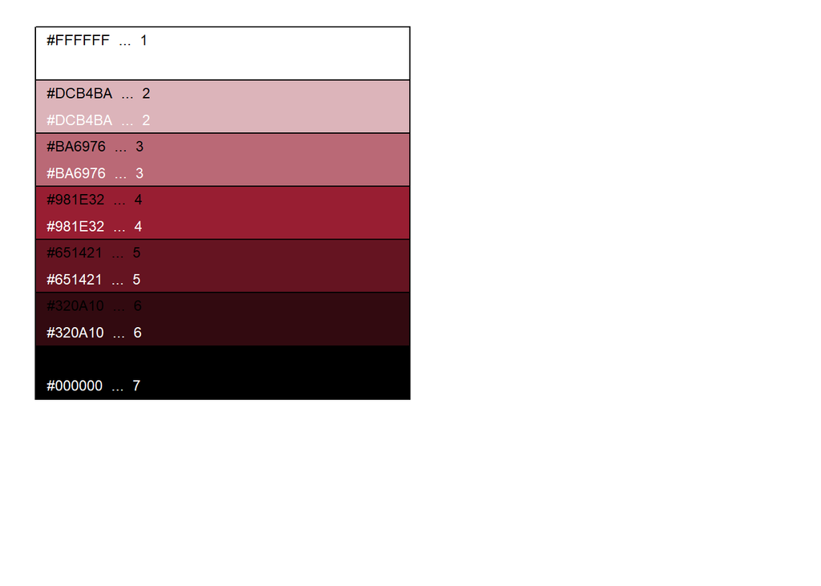

```r
###### R::humanVerse #####
color.displayColorOptions(wsu.chromatics.6$hex.color);
```

### 2.4.5 Color Gradient

`R::base` has a nice color gradient feature with some quirky syntax, so I cleaned it up a bit.

`R::base` has a nice function `col2rgb` … yet does not have the inverse function `rgb2col` (ARGH!); the `col` represents a COLOR (name), a HEX (RGB) or a HEX (RGBa).

```r
###### R::base #####
###### R::humanVerse #####
(wsu.gradient = color.colorsInGradient(10,
                    c( rgb2hex( col2rgb(wsu.crimson) ),
                       rgb2hex( col2rgb(wsu.gray)  ) ) ) );
```

```
##  [1] "#981E32" "#932738" "#8F3040" "#8B3947" "#86424D" "#824C55" "#7E555B"
##  [8] "#795E62" "#756769" "#717171"
```

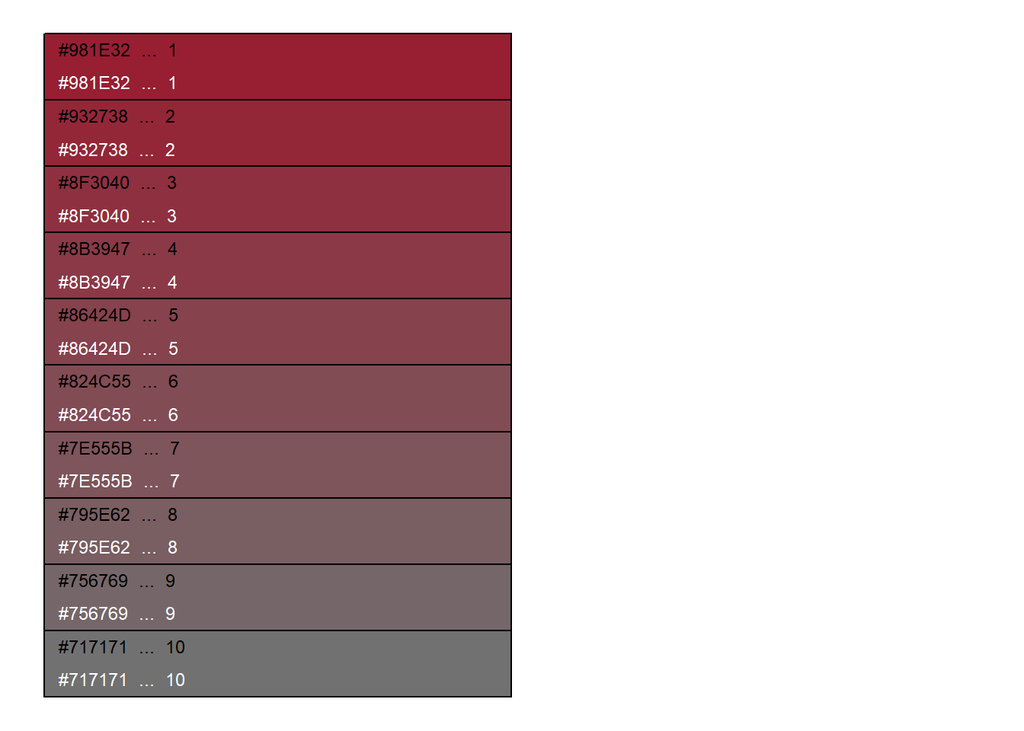

```r
color.displayColorOptions(wsu.gradient);
```

#### 2.4.5.1 (rgb2col)

It is bad software design to not have an obvious inverse function, so I wrote one. It is included in my `functions-colors.R` file.

```r
rgb2col = function(x)
  {
  # reverses col2rgb function
  x.n = dim(x)[1];
  if(x.n == 4)
    {
    x.rgb = t(x[1:4,]) /255;
    grDevices::rgb(   as.numeric(x.rgb[,1]),
                      as.numeric(x.rgb[,2]),
                      as.numeric(x.rgb[,3]),
                      as.numeric(x.rgb[,4]),
      names=rownames(x.rgb) );
    } else {
            x.rgb = t(x[1:3,]) /255;
            grDevices::rgb( x.rgb, names=rownames(x.rgb) );
            }
  }
```

### 2.4.6 Color Wheel

There are traditionally 12 colors on the color wheel, every 30 degrees of the circle.

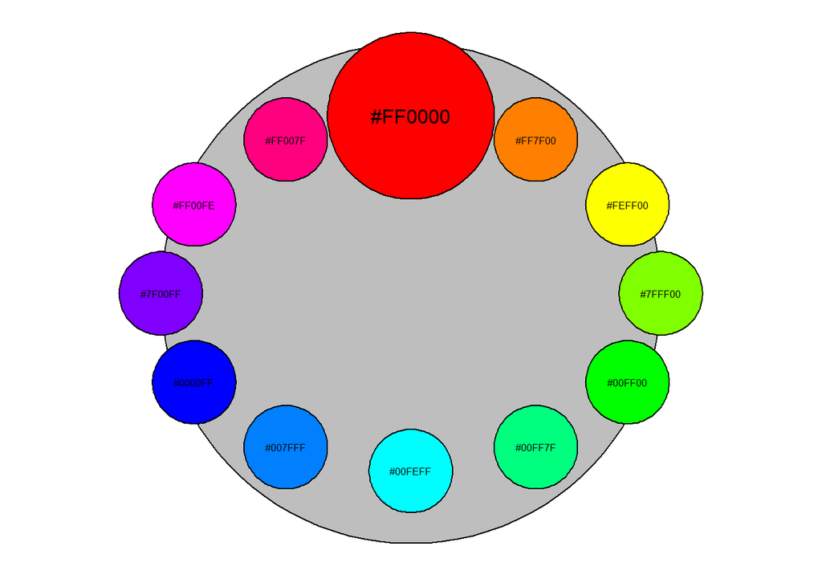

```r
library(plotrix);
###### R::humanVerse #####
color.plotWheel();
```

```r
###### R::humanVerse #####
wsu.crimson;
```

```
## [1] "#981e32"
```

```r
cat("\n", "===============", "\n\n");
(rgb = unlist ( hex2rgb( wsu.crimson ) ) );
```

```
##   r   g   b
## 152  30  50
```

```r
cat("\n", "===============", "\n\n");
(wsu.wheel = color.buildWheel(rgb) );
```

|  | degrees | hex.color | color.names | wheel |
| --- | --- | --- | --- | --- |
| 1 | 0 | #981E32 | #981E32 | 350.16393442623 |
| 2 | 30 | #98461E | ~sienna4 | 20 |
| 3 | 60 | #98831E | ~goldenrod4 | 50 |
| 4 | 90 | #6F981E | ~olivedrab | 80 |
| 5 | 120 | #32981E | ~forestgreen | 110 |
| 6 | 150 | #1E9846 | ~seagreen | 140 |
| 7 | 180 | #1E9883 | ~cyan4 | 170 |
| 8 | 210 | #1E6F98 | ~steelblue4 | 200 |
| 9 | 240 | #1E3298 | ~royalblue4 | 230 |
| 10 | 270 | #461E98 | ~purple4 | 260 |

[output cut: 2 more lines]

There is a complement, split-complement, split, triad, square, rectangle, and so on. There are just in reference to the focal color on the wheel.

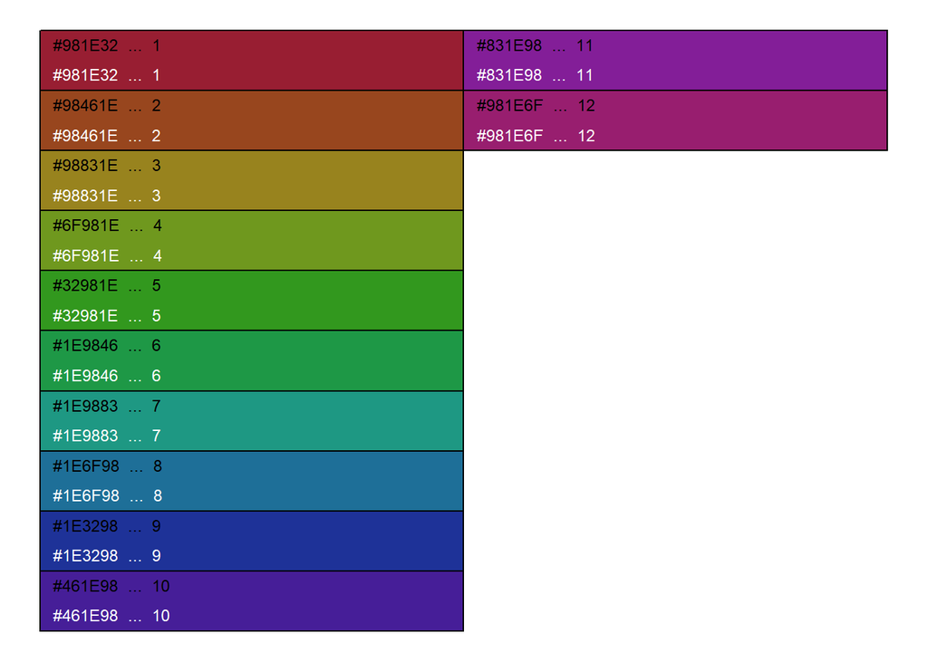

```r
###### R::humanVerse #####
color.displayColorOptions(wsu.wheel$hex.color);
```

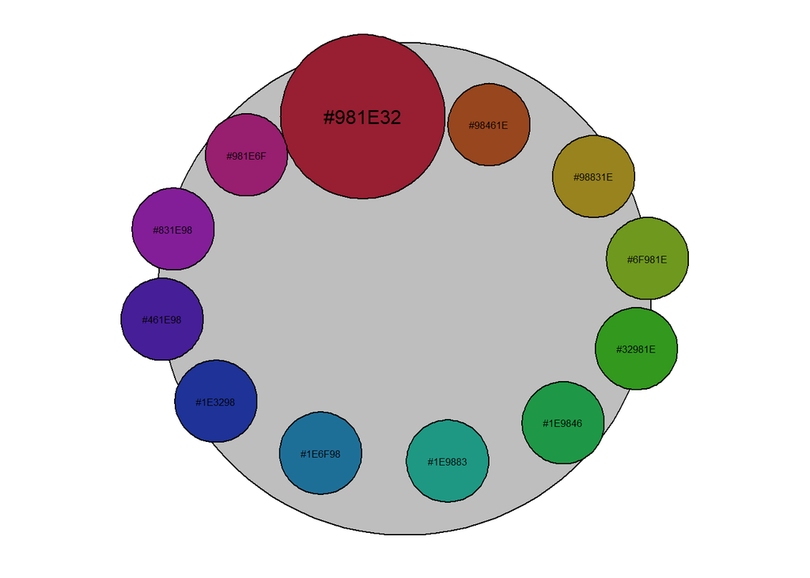

```r
###### R::humanVerse #####
color.plotWheel(wsu.wheel);
```

# 3 Color Features (R::base)

`R::base` has good color features built in.

## 3.1 Get colors by name

```r
###### R::base #####
(all.colors = colors() );
```

```
##   [1] "white"                "aliceblue"            "antiquewhite"
##   [4] "antiquewhite1"        "antiquewhite2"        "antiquewhite3"
##   [7] "antiquewhite4"        "aquamarine"           "aquamarine1"
##  [10] "aquamarine2"          "aquamarine3"          "aquamarine4"
##  [13] "azure"                "azure1"               "azure2"
##  [16] "azure3"               "azure4"               "beige"
##  [19] "bisque"               "bisque1"              "bisque2"
##  [22] "bisque3"              "bisque4"              "black"
##  [25] "blanchedalmond"       "blue"                 "blue1"
##  [28] "blue2"                "blue3"                "blue4"
##  [31] "blueviolet"           "brown"                "brown1"
##  [34] "brown2"               "brown3"               "brown4"
##  [37] "burlywood"            "burlywood1"           "burlywood2"
##  [40] "burlywood3"           "burlywood4"           "cadetblue"
##  [43] "cadetblue1"           "cadetblue2"           "cadetblue3"
```

[output cut: 204 more lines]

```r
###### R::base #####
(unique.colors = colors(TRUE) );  # removes "duplicates" ... two names with same
```

```
##   [1] "white"                "aliceblue"            "antiquewhite"
##   [4] "antiquewhite1"        "antiquewhite2"        "antiquewhite3"
##   [7] "antiquewhite4"        "aquamarine"           "aquamarine2"
##  [10] "aquamarine3"          "aquamarine4"          "azure"
##  [13] "azure2"               "azure3"               "azure4"
##  [16] "beige"                "bisque"               "bisque2"
##  [19] "bisque3"              "bisque4"              "black"
##  [22] "blanchedalmond"       "blue"                 "blue2"
##  [25] "blue3"                "blue4"                "blueviolet"
##  [28] "brown"                "brown1"               "brown2"
##  [31] "brown3"               "brown4"               "burlywood"
##  [34] "burlywood1"           "burlywood2"           "burlywood3"
##  [37] "burlywood4"           "cadetblue"            "cadetblue1"
##  [40] "cadetblue2"           "cadetblue3"           "cadetblue4"
##  [43] "chartreuse"           "chartreuse2"          "chartreuse3"
```

[output cut: 153 more lines]

```r
###### R::base #####
setdiff(all.colors, unique.colors);
```

```
##   [1] "aquamarine1"      "azure1"           "bisque1"
##   [4] "blue1"            "chartreuse1"      "cornsilk1"
##   [7] "cyan1"            "darkblue"         "darkcyan"
##  [10] "darkgrey"         "darkslategrey"    "deeppink1"
##  [13] "deepskyblue1"     "dimgrey"          "dodgerblue1"
##  [16] "gold1"            "gray0"            "gray41"
##  [19] "gray100"          "green1"           "grey"
##  [22] "grey0"            "grey1"            "grey2"
##  [25] "grey3"            "grey4"            "grey5"
##  [28] "grey6"            "grey7"            "grey8"
##  [31] "grey9"            "grey10"           "grey11"
##  [34] "grey12"           "grey13"           "grey14"
##  [37] "grey15"           "grey16"           "grey17"
##  [40] "grey18"           "grey19"           "grey20"
##  [43] "grey21"           "grey22"           "grey23"
```

[output cut: 37 more lines]

## 3.2 Data Frame: COLOR, HEX, R,G,B

I have written a function that will be a dataframe of colors with name, HEX, and RGB.

```r
###### R::humanVerse #####
color.buildTable(unique.colors);
```

| color | hex.color | r | g | b |
| --- | --- | --- | --- | --- |
| white | #FFFFFF | 255 | 255 | 255 |
| aliceblue | #F0F8FF | 240 | 248 | 255 |
| antiquewhite | #FAEBD7 | 250 | 235 | 215 |
| antiquewhite1 | #FFEFDB | 255 | 239 | 219 |
| antiquewhite2 | #EEDFCC | 238 | 223 | 204 |
| antiquewhite3 | #CDC0B0 | 205 | 192 | 176 |
| antiquewhite4 | #8B8378 | 139 | 131 | 120 |
| aquamarine | #7FFFD4 | 127 | 255 | 212 |
| aquamarine2 | #76EEC6 | 118 | 238 | 198 |
| aquamarine3 | #66CDAA | 102 | 205 | 170 |

[output cut: 492 more lines]

```r
# Wouldn't that EASTER EGG above be a nice way to display this
#   as a reference!
```

## 3.3 Find color from HEX

Using some multivariate statistics, I can compute the nearest name(s) of a color by inputing its hex.

This function looks for an exact match and returns it, or returns `how.many` based on some distance metric (difference, distance, cosine similarity).

```r
###### R::humanVerse #####
( wsu.crimson.neighbors = color.findNearestName( wsu.crimson, 10, how="difference" ) );
```

```
##  [1] "royalblue4"     "brown"          "firebrick"      "violetred4"
##  [5] "indianred4"     "salmon4"        "orangered4"     "firebrick3"
##  [9] "brown3"         "darkolivegreen"
## attr(,"match")
## [1] "difference"
## attr(,"distance")
##  [1] 0.1267160 0.4368469 0.5984802 0.6326632 0.6570179 0.8919643 0.9033715
##  [8] 0.9551002 0.9937842 1.0065477
## attr(,"hex")
##  [1] "#27408B" "#A52A2A" "#B22222" "#8B2252" "#8B3A3A" "#8B4C39" "#8B2500"
##  [8] "#CD2626" "#CD3333" "#556B2F"
```

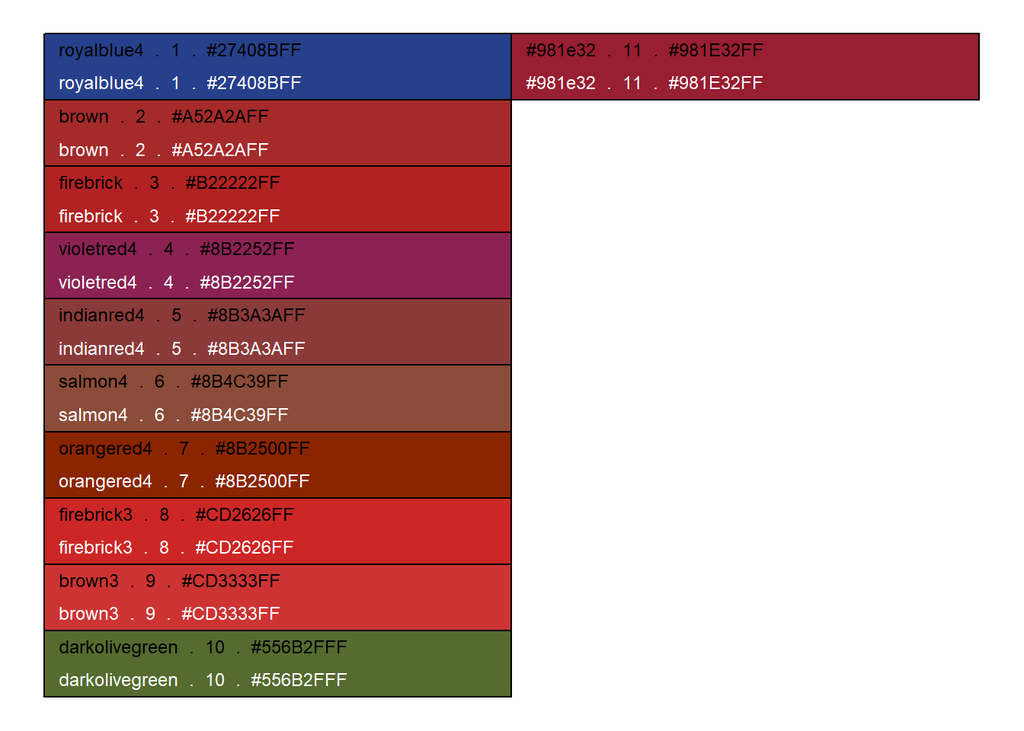

```r
color.displayColorOptions( c(wsu.crimson.neighbors, wsu.crimson),
                                                  showHEX = TRUE);
```

```r
###### R::humanVerse #####
( wsu.crimson.neighbors = color.findNearestName( wsu.crimson, 10, how="distance" ) );
```

```
##  [1] "brown"      "brown4"     "firebrick4" "firebrick"  "tomato4"
##  [6] "indianred4" "violetred4" "coral4"     "deeppink4"  "sienna4"
## attr(,"match")
## [1] "distance"
## attr(,"distance")
##  [1] 0.26 0.26 0.35 0.40 0.40 0.43 0.45 0.47 0.50 0.61
## attr(,"hex")
##  [1] "#A52A2A" "#8B2323" "#8B1A1A" "#B22222" "#8B3626" "#8B3A3A" "#8B2252"
##  [8] "#8B3E2F" "#8B0A50" "#8B4726"
```

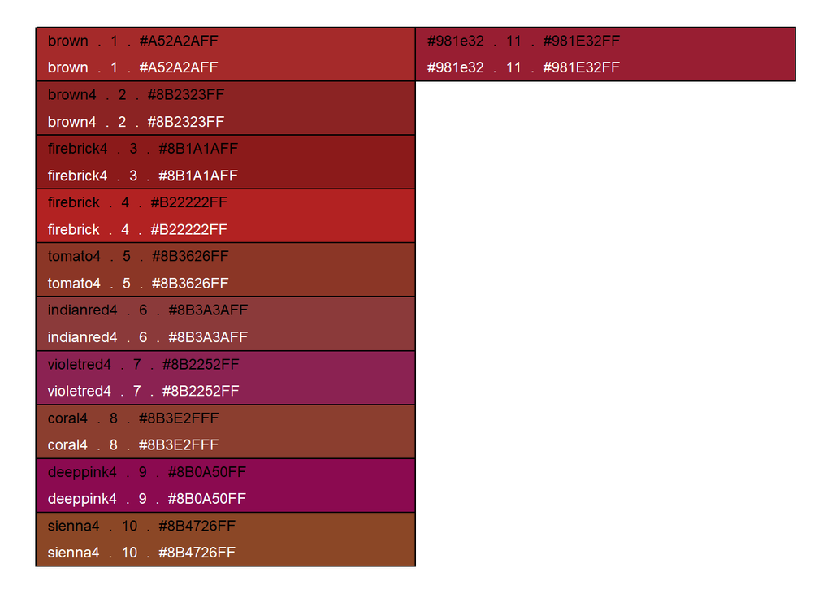

```r
color.displayColorOptions( c(wsu.crimson.neighbors, wsu.crimson),
                                                  showHEX = TRUE);
```

```r
library(lsa);
###### R::humanVerse #####
( wsu.crimson.neighbors = color.findNearestName( wsu.crimson, 10, how="cosine" ) );
```

```
##  [1] "brown4"     "brown"      "firebrick4" "tomato4"    "indianred4"
##  [6] "coral4"     "firebrick"  "violetred4" "deeppink4"  "orangered4"
## attr(,"match")
## [1] "cosine"
## attr(,"distance")
##  [1] 0.0007 0.0009 0.0011 0.0015 0.0018 0.0020 0.0021 0.0023 0.0025 0.0029
## attr(,"hex")
##  [1] "#8B2323" "#A52A2A" "#8B1A1A" "#8B3626" "#8B3A3A" "#8B3E2F" "#B22222"
##  [8] "#8B2252" "#8B0A50" "#8B2500"
```

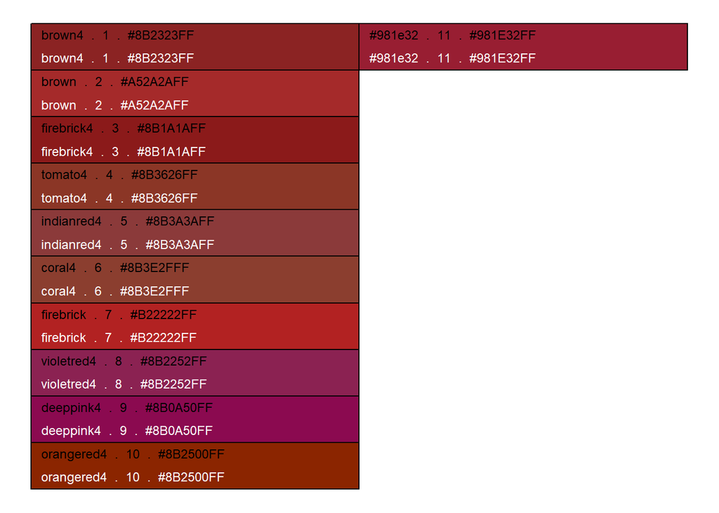

```r
color.displayColorOptions( c(wsu.crimson.neighbors, wsu.crimson),
                                                  showHEX = TRUE);
```

`how="distance"` seems to be the “best” based on accuracy/speed, although `how="cosine"` may be slightly better on accuracy. I need to see if I can write my own function to replace the library and speed this method up.

```r
###### R::humanVerse #####
( wsu.gray.neighbors = color.findNearestName( wsu.gray, 10, how="distance" ) );
```

```
##  [1] "gray44"  "gray45"  "gray43"  "gray46"  "gray42"  "gray47"  "dimgray"
##  [8] "gray48"  "gray40"  "gray49"
## attr(,"match")
## [1] "distance"
## attr(,"distance")
##  [1] 0.02 0.05 0.07 0.09 0.14 0.16 0.18 0.21 0.25 0.27
## attr(,"hex")
##  [1] "#707070" "#737373" "#6E6E6E" "#757575" "#6B6B6B" "#787878" "#696969"
##  [8] "#7A7A7A" "#666666" "#7D7D7D"
```

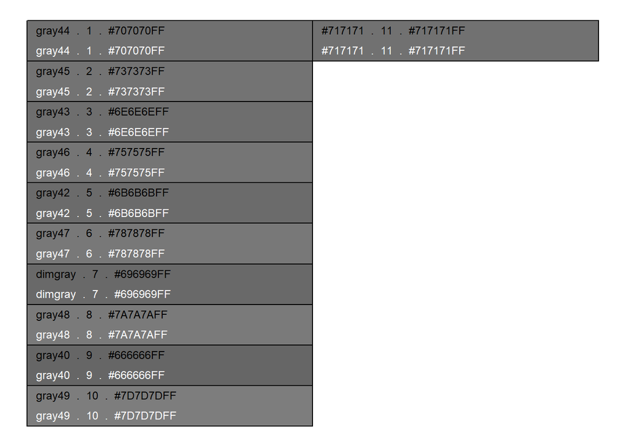

```r
color.displayColorOptions( c(wsu.gray.neighbors, wsu.gray),
                                                  showHEX = TRUE);
```

## 3.4 Built-in Palettes

`R::base` has a lot of color choices.

### 3.4.1 `rainbow`

The code below generates 40 contiguous colors using the `?rainbow` function. These values are hexadecimal RGB format https://www.w3schools.com/colors/colors_hexadecimal.asp.

```r
###### R::base #####
colors.rainbow = rainbow(40, s = 0.6, v = 0.75);
###### R::humanVerse #####
  color.displayColorOptions(colors.rainbow, ncol=4);
```

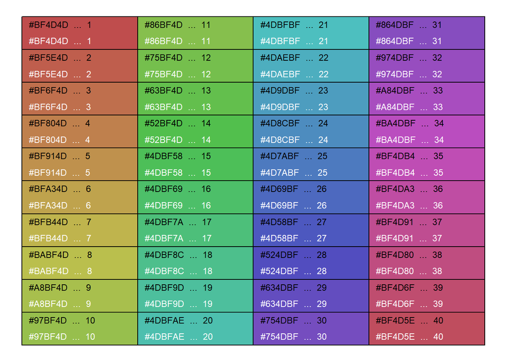

#### 3.4.1.1 Transparency: `rainbow`

The true RGB color has another element appended, “alpha transparency” also in hexadecimal form, providing a RGBa color https://www.w3schools.com/Css/css_colors_rgb.asp.

```r
###### R::base #####
colors.rainbow = rainbow(40, s = 0.6, v = 0.75,
                      alpha=0.5);
###### R::humanVerse #####
  color.displayColorOptions(colors.rainbow, ncol=4);
```

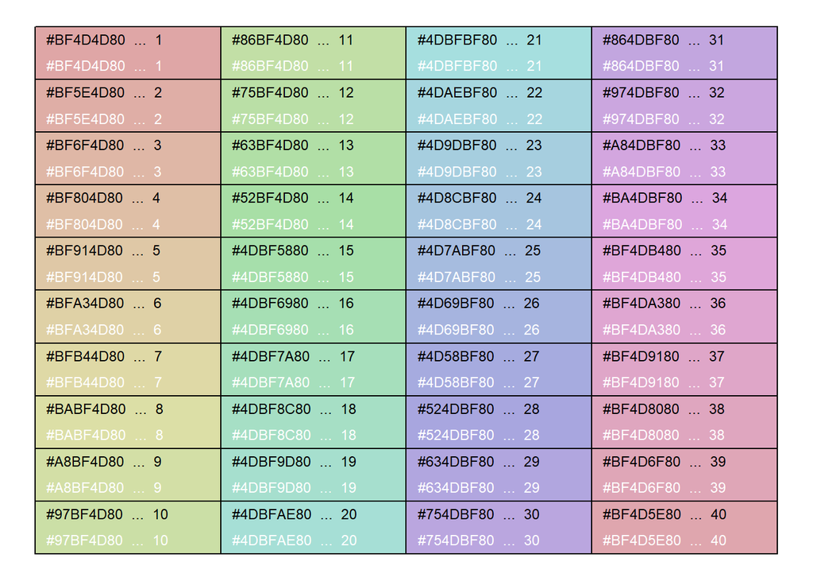

### 3.4.2 `heat.colors`

The code below generates 40 contiguous colors using the `?heat.colors` function.

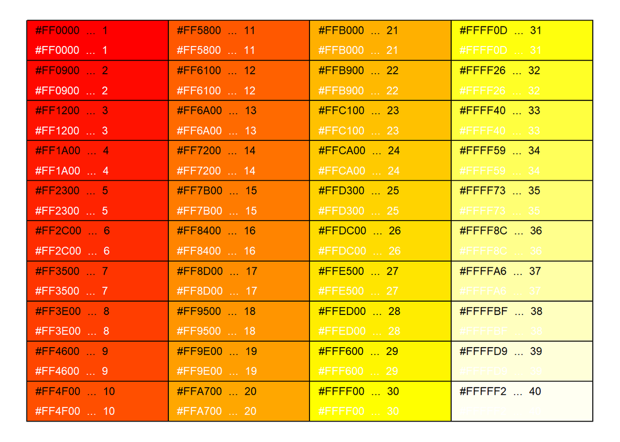

```r
###### R::base #####
colors.heat.colors = heat.colors(40);
###### R::humanVerse #####
  color.displayColorOptions(colors.heat.colors, ncol=4);
```

#### 3.4.2.1 Transparency: `heat.colors`

The code below generates 40 contiguous colors using the `?heat.colors` function.

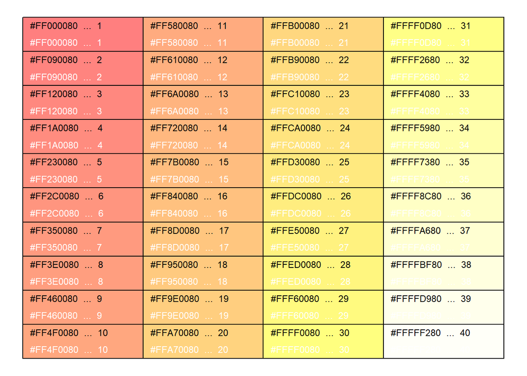

```r
###### R::base #####
colors.heat.colors = heat.colors(40, alpha=0.5);
###### R::humanVerse #####
  color.displayColorOptions(colors.heat.colors, ncol=4);
```

### 3.4.3 `terrain.colors`

The code below generates 40 contiguous colors using the `?terrain.colors` function.

```r
###### R::base #####
colors.terrain.colors = terrain.colors(40);
###### R::humanVerse #####
  color.displayColorOptions(colors.terrain.colors, ncol=4);
```

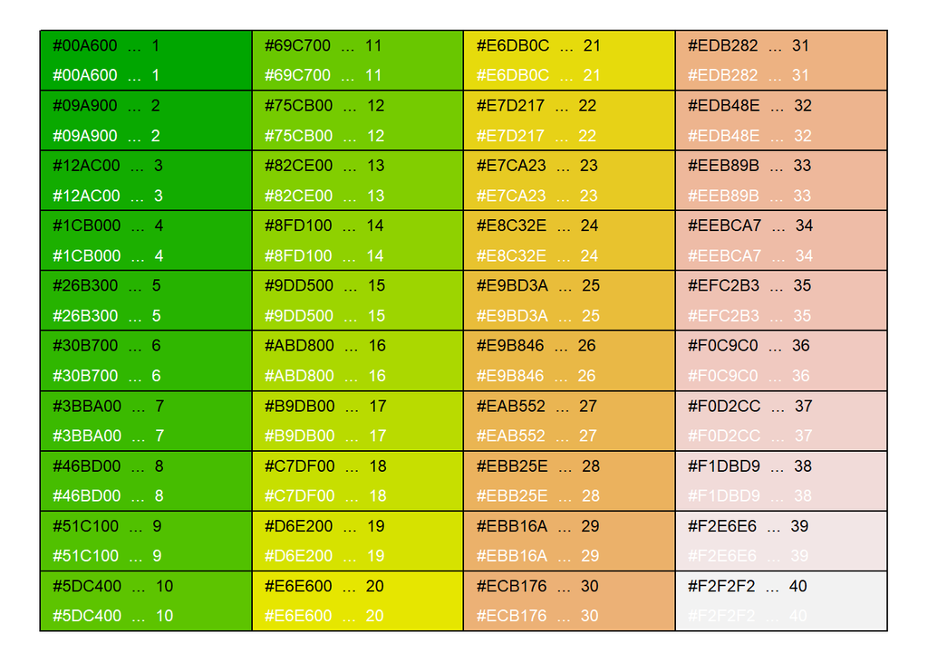

#### 3.4.3.1 Transparency: `terrain.colors`

The code below generates 40 contiguous colors using the `?terrain.colors` function.

```r
###### R::base #####
colors.terrain.colors = terrain.colors(40, alpha=0.5);
###### R::humanVerse #####
  color.displayColorOptions(colors.terrain.colors, ncol=4);
```

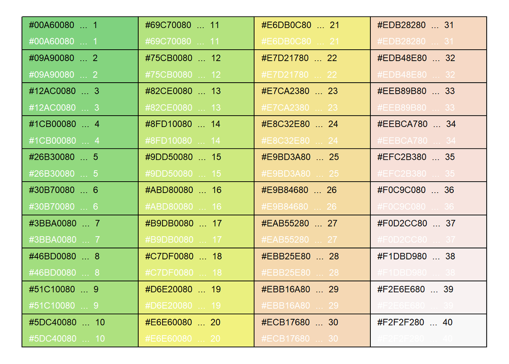

### 3.4.4 `topo.colors`

The code below generates 40 contiguous colors using the `?topo.colors` function.

```r
###### R::base #####
colors.topo.colors = topo.colors(40);
###### R::humanVerse #####
  color.displayColorOptions(colors.topo.colors, ncol=4);
```

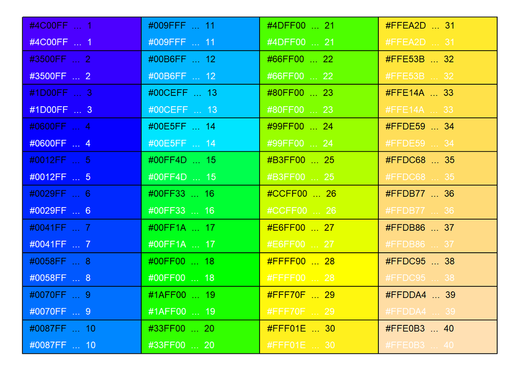

#### 3.4.4.1 Transparency: `topo.colors`

The code below generates 40 contiguous colors using the `?topo.colors` function.

```r
###### R::base #####
colors.topo.colors = topo.colors(40, alpha=0.5);
###### R::humanVerse #####
  color.displayColorOptions(colors.topo.colors, ncol=4);
```

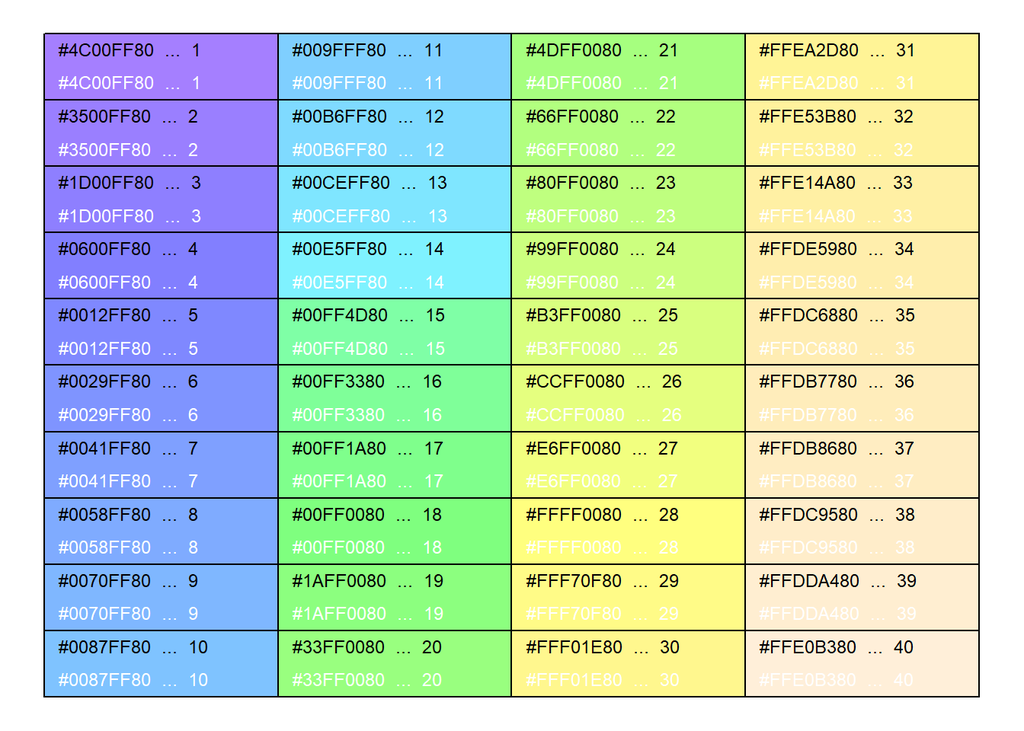

### 3.4.5 `cm.colors`

The code below generates 40 contiguous colors using the `?cm.colors` function.

```r
###### R::base #####
colors.cm.colors = cm.colors(40);
###### R::humanVerse #####
  color.displayColorOptions(colors.cm.colors, ncol=4);
```

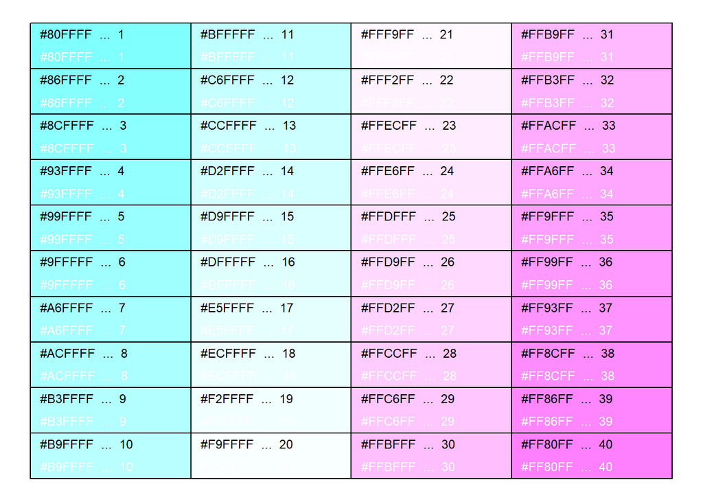

#### 3.4.5.1 Transparency: `cm.colors`

The code below generates 40 contiguous colors using the `?cm.colors` function.

```r
###### R::base #####
colors.cm.colors = cm.colors(40, alpha=0.5);
###### R::humanVerse #####
  color.displayColorOptions(colors.cm.colors, ncol=4);
```

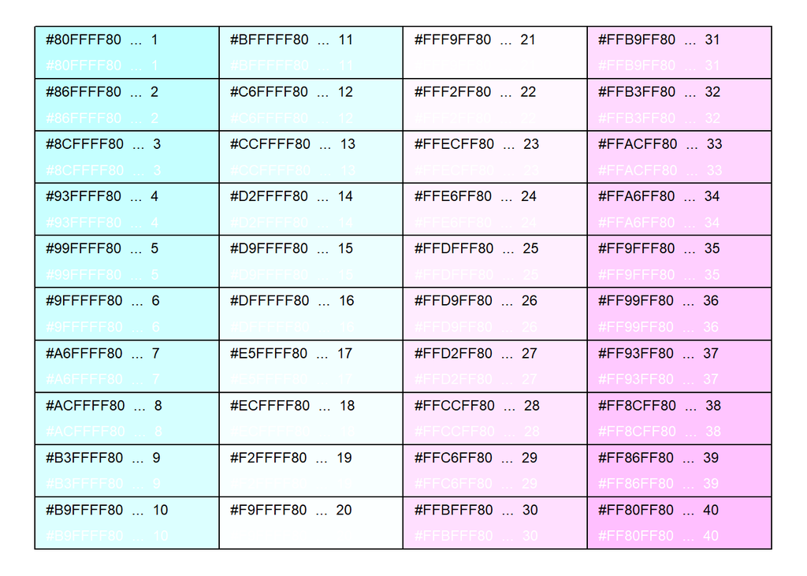

## 3.5 More Palettes (`hcl.colors`)

```r
plotPalettes = FALSE;   # set TRUE to build graphics
                        # Rendered with TRUE, is 48 MB [Knit to HTML]
###### R::base #####
hcl.palette.list = hcl.pals();

as.data.frame( hcl.palette.list );
```

| hcl.palette.list |
| --- |
| Pastel 1 |
| Dark 2 |
| Dark 3 |
| Set 2 |
| Set 3 |
| Warm |
| Cold |
| Harmonic |
| Dynamic |
| Grays |

[output cut: 100 more lines]

```r
for(i in 1:length(hcl.palette.list))
  {
  hcl = hcl.palette.list[i];
  colors.hcl.colors = hcl.colors(40, palette=hcl);

  print(paste0("Palette: ", hcl));

###### R::humanVerse #####
  if(plotPalettes)
    {
    color.displayColorOptions(colors.hcl.colors, ncol=4);
    }
  print(paste0("   ---> alpha: ", 0.5));
  colors.hcl.colors = hcl.colors(40, palette=hcl,
                                        alpha=0.5);
###### R::humanVerse #####
  if(plotPalettes)
    {
    color.displayColorOptions(colors.hcl.colors, ncol=4);
    }
  }
```

```
## [1] "Palette: Pastel 1"
## [1] "   ---> alpha: 0.5"
## [1] "Palette: Dark 2"
## [1] "   ---> alpha: 0.5"
## [1] "Palette: Dark 3"
## [1] "   ---> alpha: 0.5"
## [1] "Palette: Set 2"
## [1] "   ---> alpha: 0.5"
## [1] "Palette: Set 3"
## [1] "   ---> alpha: 0.5"
## [1] "Palette: Warm"
## [1] "   ---> alpha: 0.5"
## [1] "Palette: Cold"
## [1] "   ---> alpha: 0.5"
## [1] "Palette: Harmonic"
```

[output cut: 205 more lines]

# 4 Conclusion

Online, you can read about all these special/cool palettes developed by others libraries (e.g., “RColorBrewer” or “wesanderson”). There is nothing new or novel in these libraries. RGB and specifically RGBa are how colors are built in R (and in most user interfaces). You can do some research, and build your own palette using the information contained herein. The “pretty colors” are often a function of an “alpha” level of RGBa. And it is related to the psychological perceptions we have as to why the color is “pretty”.

## 4.1 Build Your Own

Here is me showing the official brand colors for WSU as a custom list. A few of the colors, UGH!

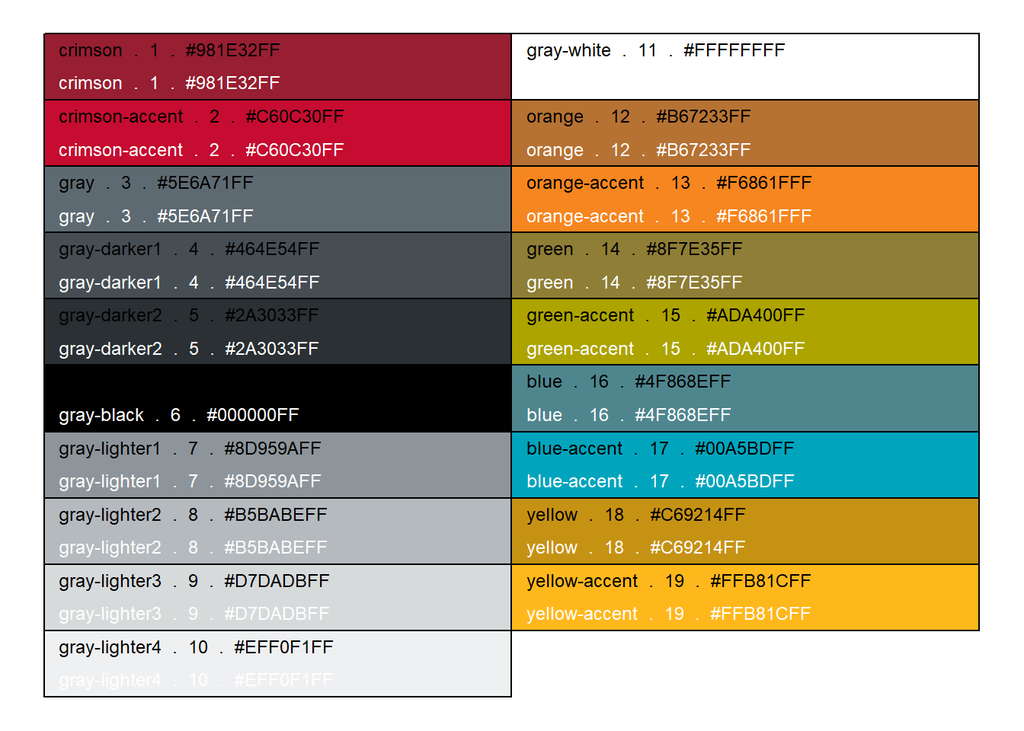

```r
# build a custom palette ...
# https://brand.wsu.edu/visual/colors/

colors.list = list();
colors.list[["monte_shaffer@wsu.edu"]] = list();

colors.list[["monte_shaffer@wsu.edu"]][["crimson"]] = "#981e32";
colors.list[["monte_shaffer@wsu.edu"]][["crimson-accent"]] = "#c60c30";
colors.list[["monte_shaffer@wsu.edu"]][["gray"]] = "#5e6a71";
colors.list[["monte_shaffer@wsu.edu"]][["gray-darker1"]] = "#464e54";
colors.list[["monte_shaffer@wsu.edu"]][["gray-darker2"]] = "#2a3033";
colors.list[["monte_shaffer@wsu.edu"]][["gray-black"]] = "#000000";
colors.list[["monte_shaffer@wsu.edu"]][["gray-lighter1"]] = "#8d959a";
colors.list[["monte_shaffer@wsu.edu"]][["gray-lighter2"]] = "#b5babe";
colors.list[["monte_shaffer@wsu.edu"]][["gray-lighter3"]] = "#d7dadb";
colors.list[["monte_shaffer@wsu.edu"]][["gray-lighter4"]] = "#eff0f1";
colors.list[["monte_shaffer@wsu.edu"]][["gray-white"]] = "#FFFFFF";
colors.list[["monte_shaffer@wsu.edu"]][["gray-lighter1"]] = "#8d959a";


colors.list[["monte_shaffer@wsu.edu"]][["orange"]] = "#b67233";
colors.list[["monte_shaffer@wsu.edu"]][["orange-accent"]] = "#f6861f";

colors.list[["monte_shaffer@wsu.edu"]][["green"]] = "#8f7e35";
colors.list[["monte_shaffer@wsu.edu"]][["green-accent"]] = "#ada400";

colors.list[["monte_shaffer@wsu.edu"]][["blue"]] = "#4f868e";
colors.list[["monte_shaffer@wsu.edu"]][["blue-accent"]] = "#00a5bd";

colors.list[["monte_shaffer@wsu.edu"]][["yellow"]] = "#c69214";
colors.list[["monte_shaffer@wsu.edu"]][["yellow-accent"]] = "#ffb81c";

# to practice, build out your own color scheme ...
mycolors = unlist(colors.list$`monte_shaffer@wsu.edu`);
color.displayColorOptions(mycolors, showHEX=TRUE, ncol=2);
```

## 4.2 TODO list

- Build some palette manager with a memory to make the visualization process more meaningful.
- Build an JSON import of a color dictionary using `library(rjson);`
- Import the “RColorBrewer” and “wesanderson” palettes using this JSON import option. HOST JSON files on Github
- Easter Eggs are obvious TODOs.